# Which screen kill runs?

First thing is first, let’s load the needed libraries and the data

```r
library(dplyr)
library(ggplot2)
library(grid)
library(gridExtra)
room_data <- read.csv("../data/fixed_room_data.csv")
room_order <- read.csv("../data/unique_room_list_double_hundo_fixed_with_index.csv", header = FALSE, col.names = c('Number','Room'))
```

Let’s start with a data frame were we calculate the number of times each room is entered and each time the run ends on the run.

```r
my_count <- room_data %>%
  group_by(Room) %>%
  summarise(times_killed_run = sum(is.na(Duration)), times_entered = length (Duration) )
```

So here’s a bit of magic you need to make sure stuff is displayed in right order. I’ll need to fix this later thougn because the order might not be 100% correct.

```r
rooms_ordered <- merge(my_count, room_order, by= "Room")
rooms_ordered$Room <-
  reorder(rooms_ordered$Room, rooms_ordered$Number)
```

And let’s make a first go at ploting this stuff up.

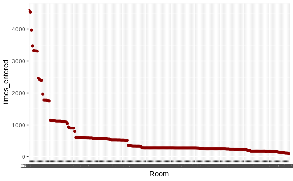

```r
ggplot(rooms_ordered, aes(y=times_entered,x=Room, f)) +
  geom_point(color = 'darkred')
```

The first thing to fix here is that there are WAY too many x-labels.

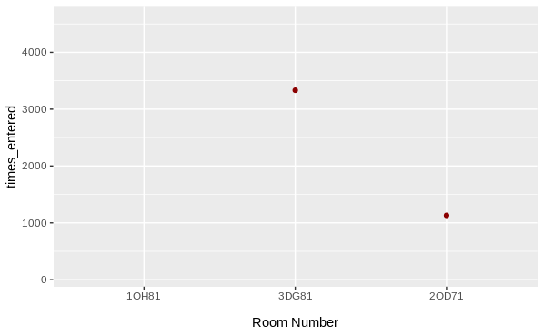

```r
ggplot(rooms_ordered, aes(y=times_entered,x=Room, f)) +
  geom_point(color = 'darkred') +
  scale_x_discrete(name="Room Number",limits=c('1OH81
', '3DG81', '2OD71'))
```

Ok so that didn’t really work like I thought it might, it filters points. Now let’s try soemthing else

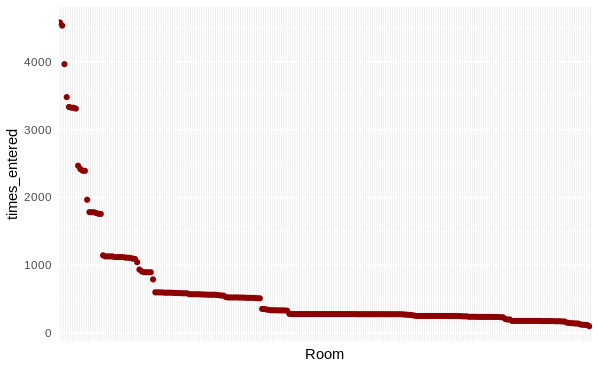

```r
ggplot(rooms_ordered, aes(y=times_entered,x=Room, f)) +
  geom_point(color = 'darkred') +
  theme(axis.text.x = element_blank(),axis.ticks = element_blank())
```

Ok that gets rid of the Room numbers which I suppose is better. Let’s try with our truncated list again

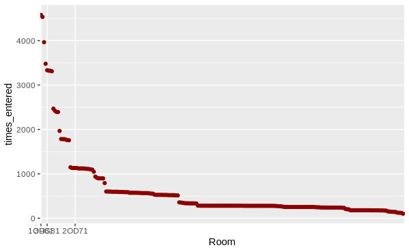

```r
ggplot(rooms_ordered, aes(y=times_entered,x=Room, f)) +
  geom_point(color = 'darkred') +
  scale_x_discrete(breaks=c('1OH81', '3DG81', '2OD71'))
```

Ok great that works. Now let’s just make a list of all those rooms to pick

```r
rooms_to_display = c('1OH81', '3DG81', '2OD71', '4DF81','3OF61', '1DF81',
                     '4OH41', ' 5DF71')
```

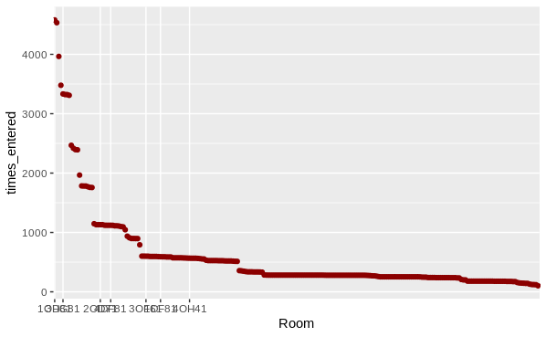

```r
ggplot(rooms_ordered, aes(y=times_entered,x=Room, f)) +
  geom_point(color = 'darkred') +
  scale_x_discrete(breaks=rooms_to_display)
```

Maybe just trying the first room each overworld and include a text rotation

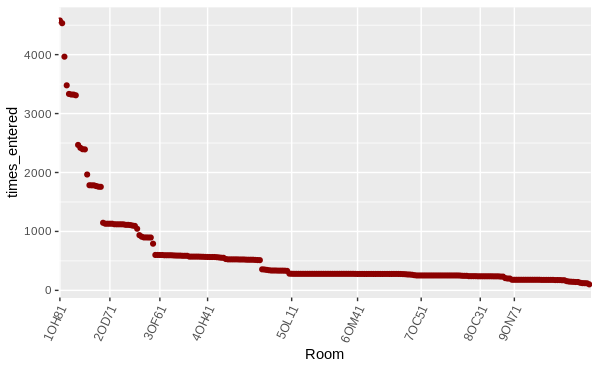

```r
rooms_to_display = c('1OH81', '2OD71', '3OF61', '4OH41', '5OL11',
                     '6OM41', '7OC51', '8OC31', '9ON71')
ggplot(rooms_ordered, aes(y=times_entered,x=Room)) +
  geom_point(color = 'darkred') +
  scale_x_discrete(breaks=rooms_to_display) +
  theme(axis.text.x = element_text(angle = 65, hjust =1))
```

Ok now let’s try some themes

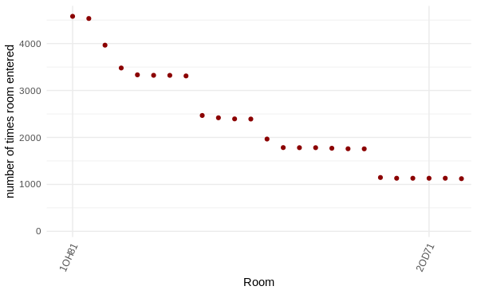

```r
rooms_to_display = c('1OH81', '2OD71', '3OF61', '4OH41', '5OL11',
                     '6OM41', '7OC51', '8OC31', '9ON71')
ggplot(rooms_ordered, aes(y=times_entered,x=Room)) +
  geom_point(color = 'darkred') +
  scale_x_discrete(breaks=rooms_to_display) +
  theme_minimal() +
  theme(axis.text.x = element_text(angle = 65, hjust =1)) +
  ylab('number of times room entered') +
  coord_cartesian(xlim = c(0,25)) +
  xlab('Room')
```

Okay well let’s take look at Room that killed runs

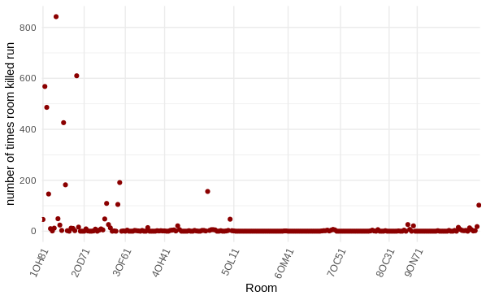

```r
rooms_to_display = c('1OH81', '2OD71', '3OF61', '4OH41', '5OL11',
                     '6OM41', '7OC51', '8OC31', '9ON71')
ggplot(rooms_ordered, aes(y=times_killed_run,x=Room)) +
  geom_point(color = 'darkred') +
  scale_x_discrete(breaks=rooms_to_display) +
  theme_minimal() +
  theme(axis.text.x = element_text(angle = 65, hjust =1)) +
  ylab('number of times room killed run') +
  #coord_cartesian(xlim = c(0,25)) +
  xlab('Room')
```

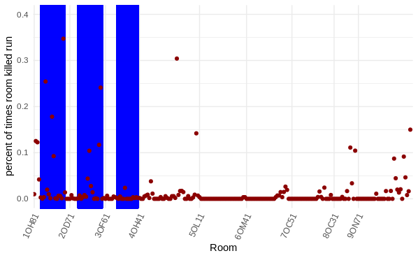

```r
rooms_to_display = c('1OH81', '2OD71', '3OF61', '4OH41', '5OL11',
                     '6OM41', '7OC51', '8OC31', '9ON71')
ggplot(rooms_ordered, aes(y=times_killed_run/times_entered,x=Room)) +
  geom_rect(aes(xmin = '3DG81', xmax = '3DH41', ymin = -Inf, ymax = Inf), alpha = 0.4 , color = 'blue',fill = 'blue') +
  geom_rect(aes(xmin = '4DF81', xmax = '4DH11', ymin = -Inf, ymax = Inf), alpha = 0.4 , color = 'blue',fill = 'blue') +
  geom_rect(aes(xmin = '1DF81', xmax = '1DI41', ymin = -Inf, ymax = Inf), alpha = 0.4 , color = 'blue',fill = 'blue') +
  geom_point(color = 'darkred') +
  scale_x_discrete(breaks=rooms_to_display) +
  theme_minimal() +
  theme(axis.text.x = element_text(angle = 65, hjust =1)) +
  ylab('percent of times room killed run') +
  coord_cartesian(ylim = c(0,0.4)) +
  xlab('Room')
```

Let’s do a quick test with ggplot, I want to know if it is possible to shorten my room rectangles.

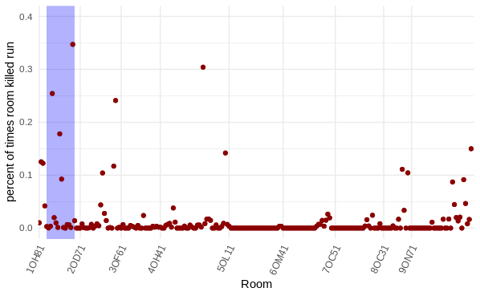

```r
add_rects <- function() {
  annotate("rect",xmin = '3DG81', xmax = '3DH41', ymin = -Inf, ymax = Inf, alpha = 0.3, fill = 'blue' )
#  geom_rect(aes(y=times_killed_run/times_entered, x = Room, xmin = '3DG81', xmax = '3DH41', ymin = -Inf, ymax = Inf), data = rooms_ordered, alpha=0.3 , fill = 'green')
}
rooms_to_display = c('1OH81', '2OD71', '3OF61', '4OH41', '5OL11',
                     '6OM41', '7OC51', '8OC31', '9ON71')
ggplot(rooms_ordered, aes(y=times_killed_run/times_entered,x=Room)) +
  geom_point(color = 'darkred') +
  add_rects() +
  geom_point(color = 'darkred') +
  scale_x_discrete(breaks=rooms_to_display) +
  theme_minimal() +
  theme(axis.text.x = element_text(angle = 65, hjust =1)) +
  ylab('percent of times room killed run') +
  coord_cartesian(ylim = c(0,0.4)) +
  xlab('Room')
```

So that work! I just have to create a function for my rooms. The only thing that is a little bit hackly is that I have to call `add_rects()` after `geom_point()` otherwise the range of the rect is incorrect, this results in rects being above the points the the coloring to be off. My current workaround for this problem is to then and another `geom_point()` call after `add_rects()` but that’s a bit hack-y for my taste since you’re ploting the points twice. I think to fix this would require a mapping between room number and room in in the `add_rects()` function but I’m not sure if that’s something I want to figure out right now.

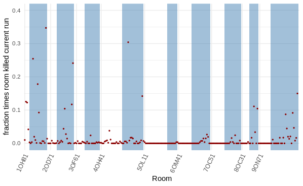

```r
add_rects_2 <- function() {
  my_alpha = 0.5
  fill_color = 'steelblue'
  list(
  annotate("rect",xmin = '3DG81', xmax = '3DH41', ymin = -Inf, ymax = Inf, alpha = my_alpha, fill = fill_color ),
  annotate("rect",xmin = '4DF81', xmax = '4DH11', ymin = -Inf, ymax = Inf, alpha = my_alpha, fill = fill_color ),
  annotate("rect",xmin = '1DF81', xmax = '1DI41', ymin = -Inf, ymax = Inf, alpha = my_alpha, fill = fill_color ),
  annotate("rect",xmin = '5DG81', xmax = '5DE21', ymin = -Inf, ymax = Inf, alpha = my_alpha, fill = fill_color ),
  annotate("rect",xmin = '2DF81', xmax = '2DF11', ymin = -Inf, ymax = Inf, alpha = my_alpha, fill = fill_color ),
  annotate("rect",xmin = '7DE81', xmax = '7DG31', ymin = -Inf, ymax = Inf, alpha = my_alpha, fill = fill_color ),
  annotate("rect",xmin = '6DE81', xmax = '6DH11', ymin = -Inf, ymax = Inf, alpha = my_alpha, fill = fill_color ),
  annotate("rect",xmin = '8DG81', xmax = '8DE31', ymin = -Inf, ymax = Inf, alpha = my_alpha, fill = fill_color ),
  annotate("rect",xmin = '9DI81', xmax = '9DE41', ymin = -Inf, ymax = Inf, alpha = my_alpha, fill = fill_color )

  )
}
rooms_to_display = c('1OH81', '2OD71', '3OF61', '4OH41', '5OL11',
                     '6OM41', '7OC51', '8OC31', '9ON71')
ggplot(rooms_ordered, aes(y=times_killed_run/times_entered,x=Room)) +
  geom_point(size = 0.1, color = 'darkred') +
  add_rects_2() +
  geom_point(size = 0.5, color = 'darkred') +
  scale_x_discrete(breaks=rooms_to_display) +
  theme_minimal() +
  theme(axis.text.x = element_text(angle = 65, hjust =1)) +
  ylab('fraction times room killed current run') +
  coord_cartesian(ylim = c(0,0.4)) +
  xlab('Room')
```

Ok let’s dive a little deeper into the analysis

```r
rooms_ordered$kill_frac <- rooms_ordered$times_killed_run / rooms_ordered$times_entered
```

In checking out this data frame I’m particularly interested in room 4ON31, aside from the first overworld section 1OXXX, this is the largest run killer in the overworld. I’m wondering if this run is the distinction between the “double hundo” route and the “30-30” route. My scraper only catches double hundo routes not 30-30.

```r
explore_runs <- room_data %>%
  filter(Room == '4ON31' ) %>%
  filter(is.na(Duration) == TRUE)
```

I now have a list of run where I can manually check for 30-30, there are 21 candidate runs here, which honestly seems a bit low. But who knows. I’m going to open up my videos and have a look.

Let’s check out run 6301, which is in my file ‘01Dec2017-2’. Ok so on this instance, he went out of order, but not exactly 30-30. I’m going to check another, 6541, in ‘06Dec2017-2’. Ok so I’ve confirmed that these runs are where the ‘double hundos’ split from the 30-30’s. I could re-do these or filter these runs out, but I think i’ll just leave them in for the time being since they represent such a small fraction of the total runs (21/4581 or 0.5%).

Ok now I want to play around with some custom room labels

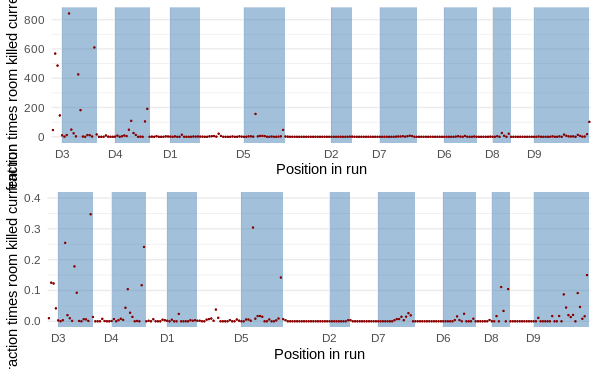

```r
dungeon_rooms = c('3DG81', '4DF81', '1DF81',
                  '5DG81', '2DF81', '7DE81',
                  '6DE81', '8DG81', '9DI81')
dungeon_display = c('3DG81' = 'D3', '4DF81' = 'D4', '1DF81' = 'D1',
                    '5DG81' = 'D5', '2DF81' = 'D2', '7DE81' = 'D7',
                    '6DE81' = 'D6', '8DG81' = 'D8', '9DI81' = 'D9')
upper_plot <- ggplot(rooms_ordered, aes(y=times_killed_run,x=Room)) +
  geom_point(size = 0.1, color = 'darkred') +
  add_rects_2() +
  geom_point(size = 0.2, color = 'darkred') +
  scale_x_discrete(breaks=dungeon_rooms, labels=dungeon_display) +
  theme_minimal() +
  #theme(axis.text.x = element_text(angle = 65, hjust =1)) +
  ylab('fraction times room killed current run') +
  #coord_cartesian(ylim = c(0,0.4)) +
  xlab('Position in run')
lower_plot <- ggplot(rooms_ordered, aes(y=kill_frac,x=Room)) +
  geom_point(size = 0.1, color = 'darkred') +
  add_rects_2() +
  geom_point(size = 0.2, color = 'darkred') +
  scale_x_discrete(breaks=dungeon_rooms, labels=dungeon_display) +
  theme_minimal() +
  #theme(axis.text.x = element_text(angle = 65, hjust =1)) +
  ylab('fraction times room killed current run') +
  coord_cartesian(ylim = c(0,0.4)) +
  xlab('Position in run')
#upper_plot + lower_plot + facet_wrap( ~ carb, nrow = 1) + theme(legend.position = "none") +
#  ggtitle("facetted plot")
grid.arrange(upper_plot, lower_plot, ncol = 1)
```

```r
#multiplot(upper_plot, lower_plot)
```

I think I might like this better as a single graph

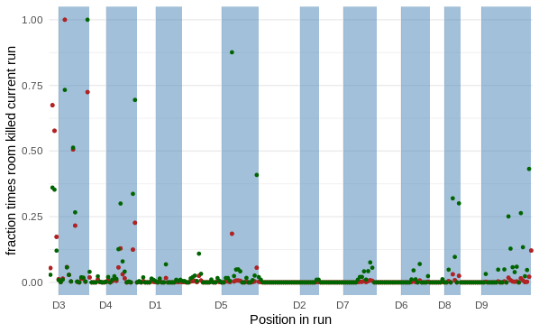

```r
# calculate the total number of runs
max_kills <- max(rooms_ordered$times_killed_run)
#rooms_ordered$kill_frac <- rooms_ordered$times_killed_run / rooms_ordered$times_entered
n <- length(rooms_ordered$kill_frac)
penultimate_kill_frac <- sort(rooms_ordered$kill_frac,partial=n-1)[n-1]
# plot combined figure
ggplot(rooms_ordered, aes(x=Room)) +
  geom_point(aes(y = times_killed_run /max_kills ), size = 1, color = 'firebrick') +
  add_rects_2() +
  geom_point(aes(y = times_killed_run/max_kills ), size = 1, color = 'firebrick') +
  geom_point(aes(y=kill_frac/penultimate_kill_frac), size = 1, color = 'darkgreen') +
  scale_x_discrete(breaks=dungeon_rooms, labels=dungeon_display) +
  theme_minimal() +
  #theme(axis.text.x = element_text(angle = 65, hjust =1)) +
  ylab('fraction times room killed current run') +
  coord_cartesian(ylim = c(0,1.0)) +
  xlab('Position in run')
```

```r
NA
```

It’s time to make some “production” level graphics for my blog post on Medium. The first one I want to make is times entered room graphic.

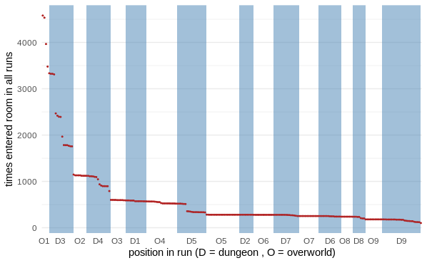

```r
# define the rectangles
dungeon_rooms_centered = c('3DD62', '4DG41', '1DE31',
                           '5DG72', '2DG51', '7DE21',
                           '6DE31', '8DG41', '9DC31')
dungeon_display_centered = c('3DD62' = 'D3', '4DG41' = 'D4', '1DE31' = 'D1',
                             '5DG72' = 'D5', '2DG51' = 'D2', '7DE21' = 'D7',
                             '6DE31' = 'D6', '8DG41' = 'D8', '9DC31' = 'D9')
overworld_rooms_centered = c('1OG81', '2OE71', '3OH61',
                             '4ON31', '5OA71', '6OE41',
                             '7OB51', '8OM41', '9OH31')
overworld_display_centered = c('1OG81' = 'O1', '2OE71' = 'O2', '3OH61' = 'O3',
                             '4ON31' = 'O4', '5OA71' = 'O5', '6OE41' = 'O6',
                             '7OB51' = 'O7', '8OM41' = 'O8', '9OH31' = 'O9')
run_rooms_centered = c(dungeon_rooms_centered, overworld_rooms_centered)
run_display_centered = c(dungeon_display_centered, overworld_display_centered)
ggplot(rooms_ordered, aes(x=Room)) +
  geom_point(aes(y = times_entered ), size = 0.3, color = 'firebrick') +
  add_rects_2() +
  geom_point(aes(y = times_entered), size = 0.3, color = 'firebrick') +
  scale_x_discrete(breaks=run_rooms_centered, labels=run_display_centered) +
  theme_minimal() +
  #theme(axis.text.x = element_text(angle = 65, hjust =1)) +
  ylab('times entered room in all runs') +
  #coord_cartesian(ylim = c(0,1.0)) +
  xlab('position in run (D = dungeon , O = overworld)') +
  theme(panel.grid.major.x = element_blank(), panel.grid.minor.x = element_blank())
```

“Don’t let great be the enemy of good.” I could probably spend another hour tinkering with this figure and maybe not have it any better. I think that I’ll leave it for the time being.